# Monitoreo Espacio-Temporal de la variación de los Glaciares Maladeta y Monte Perdido (Pirineos, España): Una Perspectiva Geomática

### **Validación del modelo. Diagnosis**

**Contraste de LJUNG‐BOX**

El Contraste de Ljung-Box (también conocido como prueba de Ljung-Box o test de Ljung-Box) es una prueba estadística utilizada para evaluar la autocorrelación en una serie temporal. Específicamente, este test examina si existe autocorrelación significativa en los residuos de un modelo ajustado, lo cual es crucial para determinar si un modelo de series temporales ha capturado adecuadamente las dependencias temporales de los datos.

**X-Squared**

El estadístico del Chi-cuadrado (X-squared) es una medida utilizada en diversas pruebas estadísticas para evaluar la relación entre variables y la adecuación de modelos. En el contexto de análisis de series temporales y el test de Box-Ljung, el estadístico del Chi-cuadrado ayuda a determinar si hay autocorrelación significativa en los residuos del modelo.

**Grados de libertad (df)**

En este caso, 20 que es un valor estándar. Los grados de libertad corresponden al número de lags o retrasos que se están probando.

**p-value**

Valor p > 0.05: El valor p es la probabilidad de observar un estadístico de prueba tan extremo como el observado, bajo la hipótesis nula. Un valor p mayor a 0.05 indica que no hay evidencia suficiente para rechazar la hipótesis nula.

Los residuos del modelo parecen ser independientes, lo que sugiere que el modelo ajustado es adecuado y que ha capturado bien la estructura de la serie temporal. Esto refuerza la validez del modelo ARIMA elegido y sugiere que no hay necesidad de añadir términos adicionales para capturar posibles dependencias en los residuos.

```r
# Prueba de Ljung-Box para verificar si los residuos son ruido blanco
residuos <- residuals(model3)
Box.test(residuos, lag = 20, type = "Ljung-Box")
```

```
    Box-Ljung test

data:  residuos
X-squared = 13.64, df = 20, p-value = 0.8483
```

El contraste de Ljung‐Box, calcula el p‐value de χ2 al percentil del 95%. Si el valor del pvalue es menor de 0.05 o de 0.01 se rechaza la hipótesis de incorrelación de los residuos.

Se necesita p‐value > 0.05.En este caso es mayor de 0.05 siendo el p-value=0.8483

**Comprobación residuos incorrelados**

calcula el estadístico de la prueba de Ljung‐Box para examinar la hipótesis nula de independencia en una serie temporal.

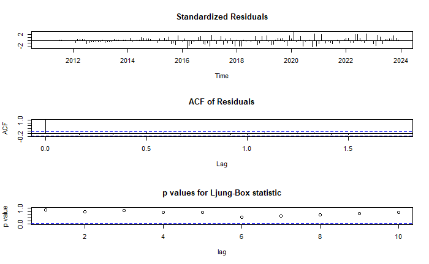

```r
diagnosis=tsdiag(model3)
```

**Standardized Residuals (Residuos estandarizados)**

Los residuos parecen estar distribuidos de manera aleatoria alrededor de cero, lo que indica que el modelo no presenta patrones evidentes no capturados. Sin embargo, la presencia de algunos picos podría sugerir que hay eventos atípicos o períodos donde el modelo no ajusta tan bien.

**ACF of Residuals (ACF de los residuos)**

No hay barras significativas que sobresalgan de los límites de significancia (las líneas punteadas), lo que sugiere que no hay autocorrelación significativa en los residuos. Esto es un buen indicio de que el modelo ha capturado correctamente las dependencias temporales en los datos.

**p values for Ljung-Box statistic (valores p para la estadística de Ljung-Box))**

Los valores p están todos por encima del nivel de significancia común (como 0.05), lo que significa que no hay evidencia significativa de autocorrelación en los residuos para los retardos probados. Esto refuerza la idea de que el modelo es adecuado.

```
$location
 [1]  63  73  84  87 110 114 118 119 120 122 137 142

$outliers
 [1] -2.599069 -2.036887 -2.000328 -2.036718  2.773572 -2.010519 -2.187673  2.152836
 [9] -2.049033  2.072843  2.024775  2.305703

$residuals
              Jan          Feb          Mar          Apr          May          Jun
2011  0.003990022  0.003421931  0.007100635  0.009342396  0.011376735  0.014198106
2012 -0.031850169 -0.766086908  0.239452742  0.245393673  0.328883921  0.428378449
2013 -0.582725917  0.064113779 -0.654268030 -0.529491231 -0.454238048 -0.410685854
2014 -0.060093818  0.731145418 -0.313456164 -0.050602071  0.068280902  0.120740555
2015  0.013049985 -0.656288832  0.479459174 -0.147034185  0.821216794  0.140028207
2016 -0.256363883  0.578616162 -2.599069117 -1.687057190 -1.099425610 -0.576488100
```

[output cut: 21 more lines]

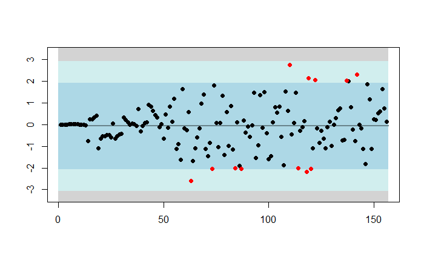

```r
residuos=model3$residuals
residout(residuos, t = 2, outplot = c(TRUE, FALSE))
```

Los puntos en rojo son aquellos residuos que están fuera de los intervalos de confianza (generalmente 95%). Esto indica que estos residuos son inusualmente grandes o pequeños, sugiriendo la presencia de posibles valores atípicos o áreas donde el modelo no está ajustando bien

Una vez realizada la validación del modelo elegido, se puede hacer la predicción de la temperatura medida en Benasque a 5 años